# Digital Marketing Campaigns Performance Analysis and Predictive Modelling with Machine Learning

Attributes:

- id: Unique identifier for each entry
- c_date: Date of the campaign
- campaign_name: Name of the campaign
- category: Category of the campaign (e.g., social, search, influencer, media)
- campaign_id: Unique identifier for each campaign
- impressions: Number of impressions generated by the campaign
- mark_spent: Amount spent on the campaign
- clicks: Number of clicks received
- leads: Number of leads generated
- orders: Number of orders made
- revenue: Revenue generated from the campaign

## 1. Exploratory Data Analysis

### 1.1. Understanding the Data, Checking Data Types, and Handling Missing Values

```python
# Import libraries

# For data manipulation
import pandas as pd
import numpy as np
from scipy import stats
from scipy.stats import randint

# For data visualisation
import seaborn as sns
import matplotlib.pyplot as plt

# For building machine learning model
from sklearn.preprocessing import LabelEncoder
from sklearn.model_selection import train_test_split, cross_val_score, RandomizedSearchCV, KFold
from sklearn.ensemble import RandomForestRegressor
from sklearn.metrics import mean_squared_error, r2_score

# For creating tables
from tabulate import tabulate
```

```python
# Load the dataset into a df
df = pd.read_csv('marketing_data.csv')

# Inspect the dataset
df.head()
```

|  | id | c_date | campaign_name | category | campaign_id | impressions | mark_spent | clicks | leads | orders | revenue |
| --- | --- | --- | --- | --- | --- | --- | --- | --- | --- | --- | --- |
| 0 | 1 | 01/02/2021 | facebook_tier1 | social | 349043 | 148263 | 67.958541 | 1210 | 13 | 1 | 46.3233 |
| 1 | 2 | 01/02/2021 | facebOOK_tier2 | social | 348934 | 220688 | 151.591860 | 1640 | 48 | 3 | 139.1466 |
| 2 | 3 | 01/02/2021 | google_hot | search | 89459845 | 22850 | 48.560880 | 457 | 9 | 1 | 74.2233 |
| 3 | 4 | 01/02/2021 | google_wide | search | 127823 | 147038 | 56.144100 | 1196 | 24 | 1 | 19.6602 |
| 4 | 5 | 01/02/2021 | youtube_blogger | influencer | 10934 | 225800 | 278.648460 | 2258 | 49 | 10 | 785.7570 |

```python
# Rename columns (where needed)
df.rename(columns={'c_date':'date', 'mark_spent':'marketing_spend'}, inplace=True)
```

```python
# Get info about the data
df.info()
```

```
<class 'pandas.core.frame.DataFrame'>
RangeIndex: 308 entries, 0 to 307
Data columns (total 11 columns):
 #   Column           Non-Null Count  Dtype
---  ------           --------------  -----
 0   id               308 non-null    int64
 1   date             308 non-null    object
 2   campaign_name    308 non-null    object
 3   category         308 non-null    object
 4   campaign_id      308 non-null    int64
 5   impressions      308 non-null    int64
 6   marketing_spend  308 non-null    float64
 7   clicks           308 non-null    int64
 8   leads            308 non-null    int64
 9   orders           308 non-null    int64
 10  revenue          308 non-null    float64
dtypes: float64(2), int64(6), object(3)
memory usage: 26.6+ KB
```

```python
# Change the data type (where needed)
df['date'] = pd.to_datetime(df['date'], format='%d/%m/%Y', dayfirst=True)
df['campaign_name'] = df['campaign_name'].astype('category')
df['category'] = df['category'].astype('category')
```

```python
# Round marketing spent and revenue to 2 decimal places
df['marketing_spend'] = df['marketing_spend'].round(2)
df['revenue'] = df['revenue'].round(2)
```

```python
# Get descriptive statistics
df.describe()
```

|  | id | date | campaign_id | impressions | marketing_spend | clicks | leads | orders | revenue |
| --- | --- | --- | --- | --- | --- | --- | --- | --- | --- |
| count | 308.000000 | 308 | 3.080000e+02 | 3.080000e+02 | 308.000000 | 308.000000 | 308.000000 | 308.000000 | 308.000000 |
| mean | 154.500000 | 2021-02-14 12:00:00 | 9.605628e+06 | 5.122475e+06 | 923.685584 | 9739.996753 | 212.918831 | 26.113636 | 1295.035909 |
| min | 1.000000 | 2021-02-01 00:00:00 | 1.093400e+04 | 6.670000e+02 | 1.580000 | 20.000000 | 0.000000 | 0.000000 | 0.000000 |
| 25% | 77.750000 | 2021-02-07 18:00:00 | 1.278230e+05 | 1.479568e+05 | 88.025000 | 1347.250000 | 20.750000 | 3.000000 | 79.795000 |
| 50% | 154.500000 | 2021-02-14 12:00:00 | 3.747540e+05 | 6.028100e+05 | 341.915000 | 4349.500000 | 84.000000 | 9.000000 | 361.925000 |
| 75% | 231.250000 | 2021-02-21 06:00:00 | 4.387490e+06 | 3.254450e+06 | 1203.157500 | 13499.250000 | 270.500000 | 29.250000 | 1274.555000 |
| max | 308.000000 | 2021-02-28 00:00:00 | 8.945984e+07 | 4.199700e+08 | 8187.320000 | 61195.000000 | 1678.000000 | 369.000000 | 26156.440000 |
| std | 89.056162 | NaN | 2.543040e+07 | 2.631134e+07 | 1339.274824 | 12157.476244 | 300.459978 | 42.741288 | 2569.619126 |

```python
# Check for missing values
df.isnull().sum()
```

```
id                 0
date               0
campaign_name      0
category           0
campaign_id        0
impressions        0
marketing_spend    0
clicks             0
leads              0
orders             0
revenue            0
dtype: int64
```

```python
# Check for duplicates
df.duplicated().sum()
```

```
0
```

##### Comments

- Data types were changed (where needed)
- Columns were renamed (where needed)
- The dataset did not have any missing values or duplicates
- The dataset is ready for analysis

### 1.2. Detecting and Handling Outliers

```python
# Write function to detect outliers

def detect_outliers(df, column):
    Q1 = df[column].quantile(0.25) # Calculate 25th percentile
    Q3 = df[column].quantile(0.75) # Calculate 75th percentile
    IQR = Q3 - Q1 # Calculate IQR
    lower_bound = Q1 - 1.5 * IQR # Define lower bound
    upper_bound = Q3 + 1.5 * IQR # Define upper bound
    outliers = df[(df[column] < lower_bound) | (df[column] > upper_bound)] # Find outliers

    # Print the results
    print(f"Outliers detected in '{column}':")
    print(outliers[column])
    print(f"Number of outliers: {outliers.shape[0]}")
    print(f"Lower bound: {lower_bound}; Upper bound: {upper_bound}")
```

```python
# Detect ouliers
columns = ['impressions', 'marketing_spend', 'clicks', 'leads', 'orders', 'revenue']
for column in columns:
    detect_outliers(df, column)
```

```
Outliers detected in 'impressions':
10      20900000
21      42000000
32     125910000
43      41924802
47       9914040
54       8238872
65      42070000
131     10819771
142     17890507
144      7936534
164      8747458
171     15988504
175     56876855
182     32964848
```

[output cut: 201 more lines]

```python
# Write function to visualise ouliers

def visualise_outliers(df, columns):
    num_rows = (len(columns) + 1) // 2 # Ensure that the last row will display a plot even if the number of plots is odd
    fig, axes = plt.subplots(num_rows, 2, figsize=(15, 5*num_rows)) # Plot displaying 2 plots on each row
    axes = axes.flatten() # Convert the axes array (which is a 2D array when there are multiple rows and columns of subplots) into a 1D array

    # If there is only 1 plot, then I need to convert it into a list so that I can use it in the same way as when there are multiple subplots
    if len(columns) == 1:
        axes = [axes]

    # Plot boxplots
    for i, column in enumerate(columns):
        sns.boxplot(x=df[column], ax=axes[i])
        axes[i].set_title(f"Boxplot of {column.capitalize()}")

        # Turn off unused axes to avoid displaying empty plots
        for j in range (len(columns), len(axes)):
            axes[j].axis('off')

    plt.tight_layout(pad=2)
    plt.show()
```

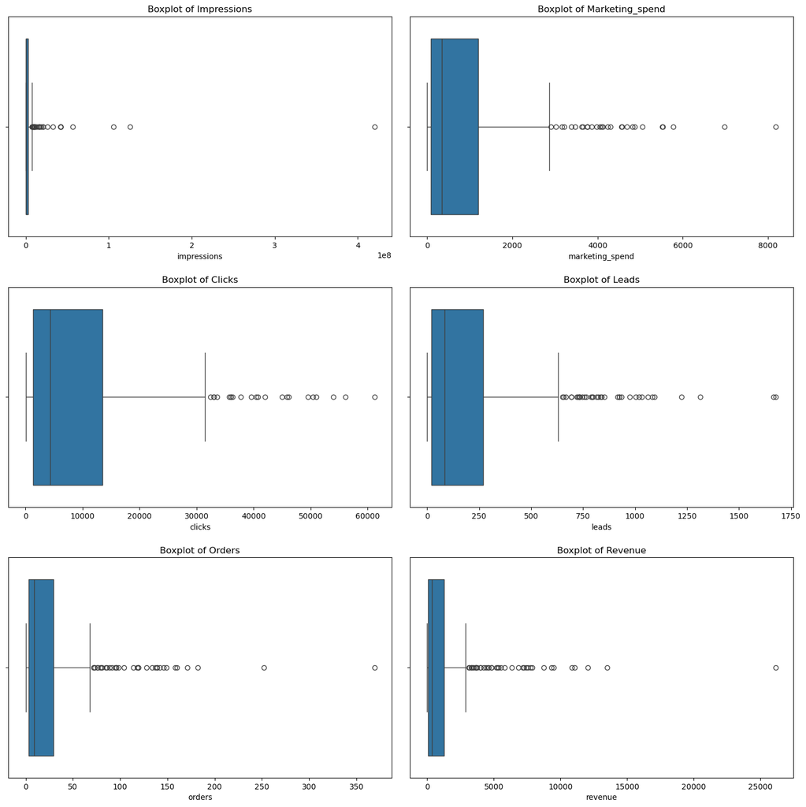

```python
# Visualise outliers

columns = ['impressions', 'marketing_spend', 'clicks', 'leads', 'orders', 'revenue']
visualise_outliers(df, columns)
```

##### Comments

- Outliers were identified and visualised (using boxplots)
- All six columns have outliers ranging from 22 to 39 per column
- 'impressions' column has the most extreme outliers with values in the order of magnitude of 10^7 to 10^8
- Since I cannot determine if outliers are valid data point (rare but significant) or errors, I will not remove or modify them. I will keep the outliers for now and modify / delete them during the machine learning model building stage (if needed)

### 1.3. Statistical Analysis and Data Visualisation

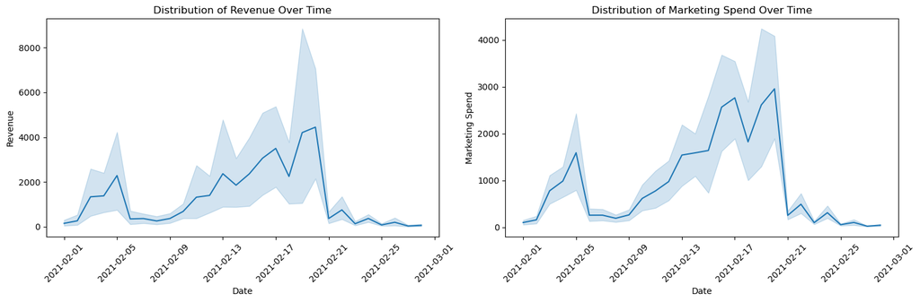

```python
# Plot revenue and marketing spent over time

fig, axes = plt.subplots(1, 2, figsize=(15,5))

sns.lineplot(x=df['date'], y=df['revenue'], ax=axes[0])
axes[0].set_title('Distribution of Revenue Over Time')
axes[0].set_xlabel('Date')
axes[0].set_ylabel('Revenue')

sns.lineplot(x=df['date'], y=df['marketing_spend'], ax=axes[1])
axes[1].set_title('Distribution of Marketing Spend Over Time')
axes[1].set_xlabel('Date')
axes[1].set_ylabel('Marketing Spend')

# Rotate x-axis tick labels
for ax in axes:
    ax.tick_params(axis='x', rotation=45)

plt.tight_layout()
plt.show()
```

##### Comments

Both revenue and marketing spend have similar distribution over time:

- In the beginning of February, the values were average, then they fell, then there was a spike (a more significant one for marketing spend), and then again the fall, resulting in very low numbers closer to the end of February

```python
# Write function to plot key metrics

def plot_key_metrics(df, key_metrics):
    num_rows = (len(key_metrics) + 1) // 2 # Ensure that the last row will display a plot even if the number of plots is odd
    fig, axes = plt.subplots(num_rows, 2, figsize=(15, 5*num_rows)) # Plot displaying 2 plots on each row
    axes = axes.flatten() # Convert the axes array (which is a 2D array when there are multiple rows and columns of subplots) into a 1D array

    # If there is only 1 plot, then I need to convert it into a list so that I can use it in the same way as when there are multiple subplots
    if len(key_metrics) == 1:
        axes = [axes]

    # Plot boxplots
    for i, key_metric in enumerate(key_metrics):
        sns.histplot(x=df[key_metric], bins=30, kde=True, ax=axes[i])
        axes[i].set_title(f"Boxplot of {key_metric.capitalize()}")
        axes[i].set_xlabel(f"{key_metric.capitalize()}")

    # Turn off unused axes to avoid displaying empty plots
    for j in range (len(key_metrics), len(axes)):
        axes[j].axis('off')

    plt.tight_layout(pad=2)
    plt.show()
```

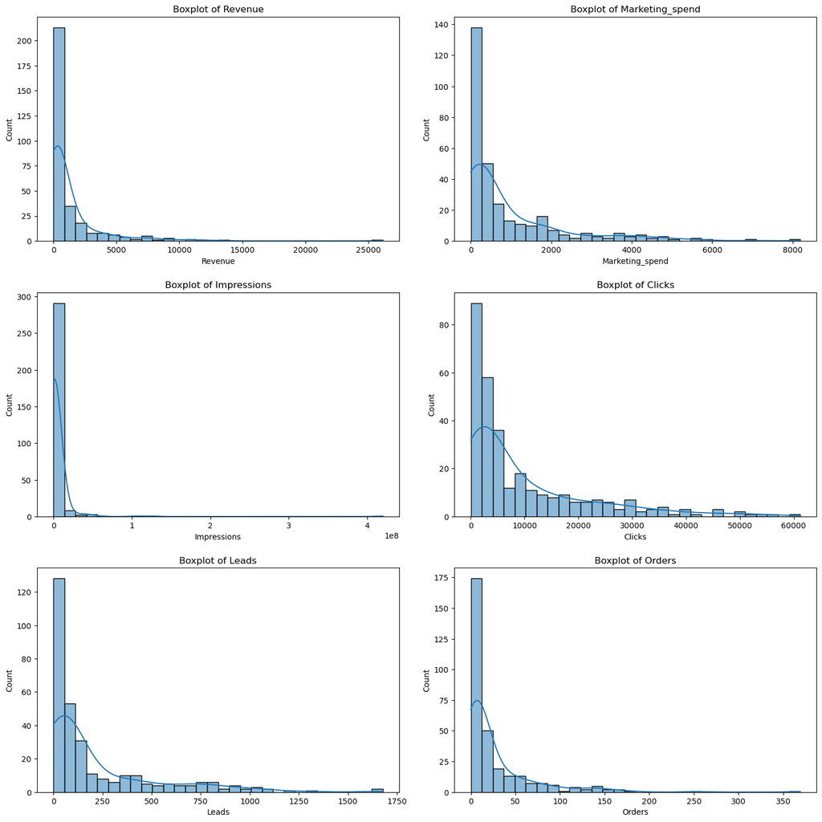

```python
# Plot key metrics

key_metrics = ['revenue', 'marketing_spend', 'impressions', 'clicks', 'leads', 'orders']
plot_key_metrics(df, key_metrics)
```

##### Comments

All histograms are highly right-skewed, with a significant number of low and zero values; that is why the distribution of higher values is difficult to read. To fix this, I will create new columns doing log transformation of the key metrics and plot them. I will use the log1p transformation, which adds 1 before taking the logarithm in order to handle value = 0.

```python
# Perform log transformation for key metrics

df['log_impressions'] = np.log1p(df['impressions'])
df['log_clicks'] = np.log1p(df['clicks'])
df['log_leads'] = np.log1p(df['leads'])
df['log_orders'] = np.log1p(df['orders'])
df['log_revenue'] = np.log1p(df['revenue'])
df['log_marketing_spend'] = np.log1p(df['marketing_spend'])
```

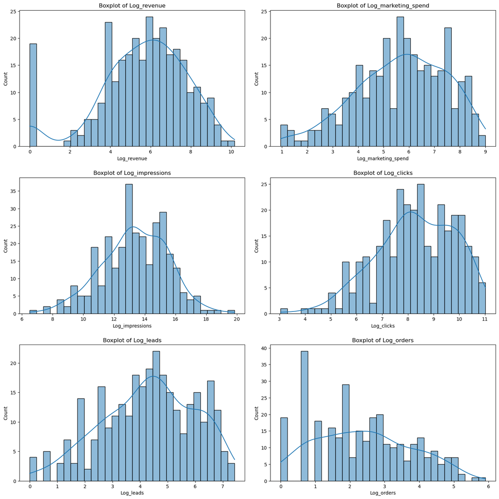

```python
# Plot log key metrics

log_key_metrics = ['log_revenue', 'log_marketing_spend', 'log_impressions', 'log_clicks', 'log_leads', 'log_orders']
key_metrics = log_key_metrics
plot_key_metrics(df, key_metrics)
```

##### Comments

After applying the log transformation, the distribution (of all key metrics) is easier to read.

Revenue Plot:

- There is a spike at 0, meaning that there are many values of 0
- There are 2 spikes at around 4 and 6, meaning there are many values of 53.6 and 402.4, respectively

Marketing Spend Plot:

- There are no values of 0, meaning that each campaign has some money invested in it
- The histogram is slightly left-skewed, meaning that more often higher amount was spent on marketing

Impressions Plot:

- There is a significant spike at around 13, meaning that many values are near 442412.4

Clicks Plot:

- The histogram is left-skewed, meaning that each campaign attracted a significant number of clicks

Leads Plot

- The histogram is less left-skewed than the Clicks Plot; however, still the number of leads is usually higher

Orders Plot

```python
# Calculate original value
def find_original_value(log1p_value):
    original_value = np.expm1(log1p_value)
    print(f"Original value is: {original_value}")

# Calculate log1p value
def find_log1p_value(original_value):
    log1p_value = np.log1p(original_value)
    print(f"Log1p value is: {log1p_value}")

# Find values

find_original_value(1.7)
find_log1p_value(1)
```

```
Original value is: 4.4739473917272
Log1p value is: 0.6931471805599453
```

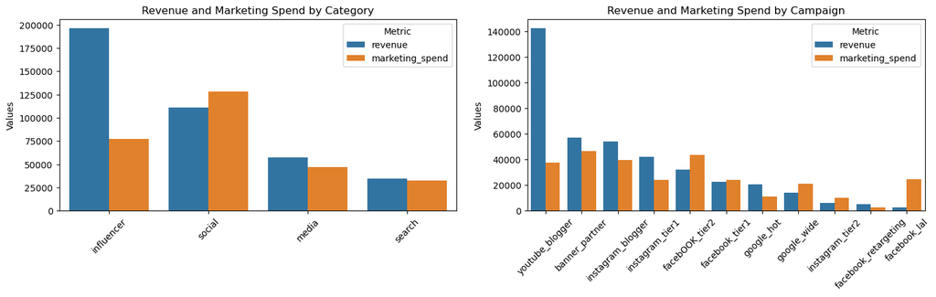

```python
# Calculate the sum of revenue and marketing spend for each category and campaign
categories_totals = df.groupby('category', observed=True)[['revenue', 'marketing_spend']].sum().reset_index()
campaigns_totals = df.groupby('campaign_name', observed=True)[['revenue', 'marketing_spend']].sum().reset_index()

# Sort categories and campaigns by revenue
categories_totals = categories_totals.sort_values(by='revenue', ascending=False)
campaigns_totals = campaigns_totals.sort_values(by='revenue', ascending=False)

# Melt the df to have a 'long format' suitable for plotting
df_melted_categories = categories_totals.melt(id_vars=['category'], value_vars=['revenue', 'marketing_spend'], var_name='Metric', value_name='Values')
df_melted_campaigns = campaigns_totals.melt(id_vars=['campaign_name'], value_vars=['revenue', 'marketing_spend'], var_name='Metric', value_name='Values')

# Plot the sum of revenue and marketing spend for each category and campaign
fig, axes = plt.subplots(1, 2, figsize=(15, 5))

sns.barplot(x='category', y='Values', hue='Metric', data=df_melted_categories, order=categories_totals['category'], ax=axes[0])
axes[0].set_title('Revenue and Marketing Spend by Category')
axes[0].set_xlabel('')

sns.barplot(x='campaign_name', y='Values', hue='Metric', data=df_melted_campaigns, order=campaigns_totals['campaign_name'], ax=axes[1])
axes[1].set_title('Revenue and Marketing Spend by Campaign')
axes[1].set_xlabel('')

# Rotate x-axis tick labels
for ax in axes:
    ax.tick_params(axis='x', rotation=45)

plt.tight_layout(pad=2)
plt.show()
```

##### Comments

Categories:

- Based on the revenue, the influencer category is the most successful one with the sum of revenue of almost £200,000. The marketing spend on this category is £75,000, which is not the highest one and is significantly smaller than the revenue made.
- The social category made a rvenue of slighly more than £100,000; however, the marketing spend is higher - £125,000; which is not a good sign.
- The least successful category is the search category with the revenue and marketing spend being approximately the same - around £37,000.

Campaigns:

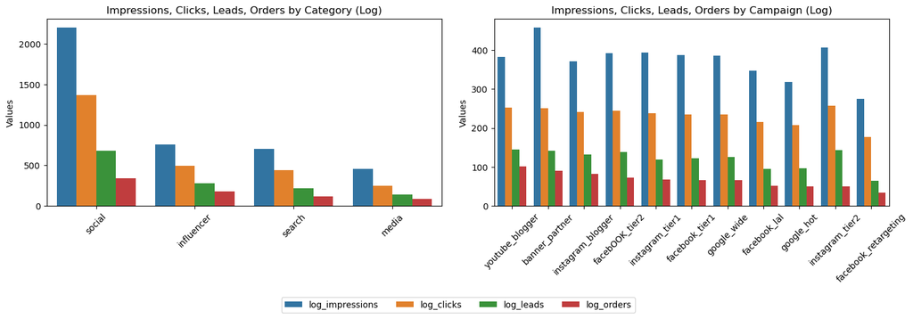

```python
# Calculate the sum of impressions, clicks, leads, orders for each category and campaign
categories_totals_metrics = df.groupby('category', observed=True)[['log_impressions', 'log_clicks', 'log_leads', 'log_orders']].sum().reset_index()
campaigns_totals_metrics = df.groupby('campaign_name', observed=True)[['log_impressions', 'log_clicks', 'log_leads', 'log_orders']].sum().reset_index()

# Sort categories and campaigns by orders
categories_totals_metrics = categories_totals_metrics.sort_values(by='log_orders', ascending=False)
campaigns_totals_metrics = campaigns_totals_metrics.sort_values(by='log_orders', ascending=False)

# Melt the df to have a 'long format' suitable for plotting
df_melted_categories_metrics = categories_totals_metrics.melt(id_vars=['category'], value_vars=['log_impressions', 'log_clicks', 'log_leads', 'log_orders'], var_name='Metric', value_name='Values')
df_melted_campaigns_metrics = campaigns_totals_metrics.melt(id_vars=['campaign_name'], value_vars=['log_impressions', 'log_clicks', 'log_leads', 'log_orders'], var_name='Metric', value_name='Values')

# Plot the sum of impressions, clicks, leads, orders for each category and campaign
fig, axes = plt.subplots(1, 2, figsize=(15, 5))

sns.barplot(x='category', y='Values', hue='Metric', data=df_melted_categories_metrics, order=categories_totals_metrics['category'], ax=axes[0])
axes[0].set_title('Impressions, Clicks, Leads, Orders by Category (Log)')
axes[0].set_xlabel('')
axes[0].get_legend().remove()

sns.barplot(x='campaign_name', y='Values', hue='Metric', data=df_melted_campaigns_metrics, order=campaigns_totals_metrics['campaign_name'], ax=axes[1])
axes[1].set_title('Impressions, Clicks, Leads, Orders by Campaign (Log)')
axes[1].set_xlabel('')
axes[1].get_legend().remove()

# Rotate x-axis tick labels
for ax in axes:
    ax.tick_params(axis='x', rotation=45)

# Create a single legend
handles, labels = axes[0].get_legend_handles_labels() # Get handles and labels from the first plot
fig.legend(handles, labels, loc='lower center', bbox_to_anchor=(0.5, -0.05), ncol=4)

plt.tight_layout(pad=2)
plt.show()
```

##### Comments

Since the distribution of values of key metrics (impressions, clicks, orders, leads) is too large, I visualised log transformed version of these metrics.

- The barplots above show that the sum of impressions compared to other values is significantly larger - the next variable is clicks, then leads, and the smallest one is orders. I sorted the barplots to show the highest number of orders; and (with an exception of a few campaigns' impressions and clicks) all other key metrics follow the same distribution - meaning that the for the highest number of orders, there is the highest number of impressions, clicks, and leads.

Categories Plot:

- The highest number of all key metrics was achieved by the social category.

Campaigns Plot:

- The highest number of orders was achieved by the youtube_blogger campaign.
- However, the highest number of impressions was achieved by banner_partner (this campaign achieved the second highest number of orders).
- The highest number of clicks and the second highest number of impressions was achieved by instagram_tier2; however, this campaign achieved only the second lowest number of orders.

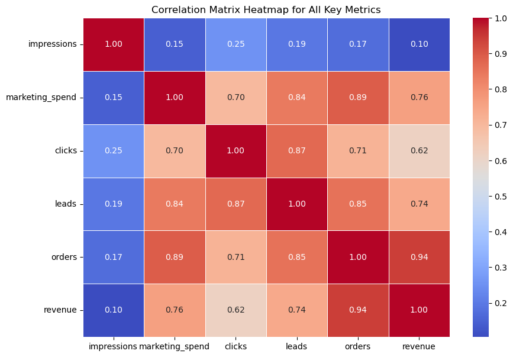

```python
# Plot a correlation matrix for all key metrics

key_metrics = df[['impressions', 'marketing_spend', 'clicks', 'leads', 'orders', 'revenue']]

correlation_matrix = key_metrics.corr()

plt.figure(figsize=(10,7))
sns.heatmap(correlation_matrix, annot=True, cmap='coolwarm', fmt='.2f', linewidth=0.5)
plt.title('Correlation Matrix Heatmap for All Key Metrics')
plt.show()
```

##### Comments

- A weak / almost no correlation is between impressions and other metrics (<= 0.25)
- All metrics besides impressions have a moderate to strong correlation
- The strongest correlation is between revenue and order (which makes sense since the more orders, the higher the revenue) and between orders and marketing spend (which shows that the more money is invested in marketing, the more orders it generates). However, it is interesting that the correlation between revenue and marketing spend is significantly lower (0.76)

## 2. Feature Engineering

##### Comments

To improve the analysis, I will create additional marketing metrics, such as:

1. ROMI helps measure the effectiveness of marketing campaigns by showing how much revenue is generated for every dollar spent on marketing.

$$ \text{ROMI (Return on Marketing Investment)} = \frac{\text{Revenue} - \text{Marketing Spend}}{\text{Marketing Spend}} \times 100 $$

2. CTR measures how often people click on an ad or link after seeing it.

$$ \text{CTR (Click-Through Rate)} = \frac{\text{Total Number of Clicks}}{\text{Total Number of Impressions}} \times 100 $$

3. Conversion Rate shows how effective the website (or landing page) is at converting clicks into actual actions (e.g., sales)

$$ \text{Conversion Rate} = \frac{\text{Total Number of Conversions (e.g., Orders)}}{\text{Total Number of Clicks}} \times 100 $$

4. AOV measures the average revenue generated per order.

$$ \text{AOV (Average Order Value)} = \frac{\text{Total Revenue}}{\text{Total Number of Orders}} $$

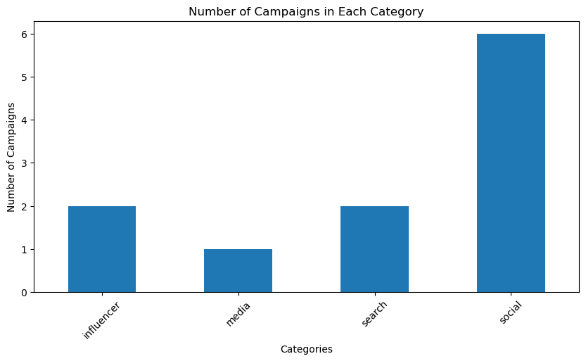

```python
# Visualise the number of campaigns in each category

campaign_counts = df.groupby('category', observed=True)['campaign_name'].nunique()
plt.figure(figsize=(10,5))
campaign_counts.plot(kind='bar')
plt.title('Number of Campaigns in Each Category')
plt.xlabel('Categories')
plt.ylabel('Number of Campaigns')
plt.xticks(rotation=45)
plt.show()
```

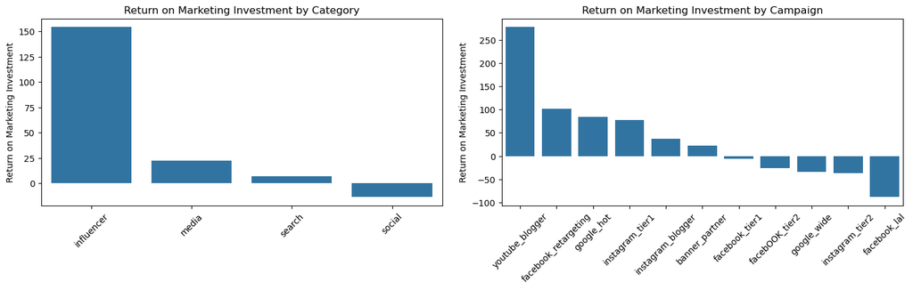

```python
# Calculate ROMI for categories and campaigns

# For categories
categories_romi = df.groupby('category', observed=True).agg(
    total_revenue=('revenue', 'sum'),
    total_marketing_spend=('marketing_spend', 'sum')
).reset_index()
categories_romi['romi'] = ((categories_romi['total_revenue'] - categories_romi['total_marketing_spend']) /
                           (categories_romi['total_marketing_spend']) * 100)
df = df.merge(categories_romi[['category', 'romi']], on='category', how='left')
df.rename(columns={'romi': 'categories_romi'}, inplace=True)

# For campaigns
campaigns_romi = df.groupby('campaign_name', observed=True).agg(
    total_revenue = ('revenue', 'sum'),
    total_marketing_spend=('marketing_spend', 'sum')
).reset_index()
campaigns_romi['romi'] = ((campaigns_romi['total_revenue'] - campaigns_romi['total_marketing_spend']) /
                          (campaigns_romi['total_marketing_spend']) * 100)
df = df.merge(campaigns_romi[['campaign_name', 'romi']], on='campaign_name', how='left')
df.rename(columns={'romi': 'campaigns_romi'}, inplace=True)

# Plot ROMI for categories and campaigns

# Sort the df by ROMI
sorted_categories_romi = categories_romi.sort_values(by='romi', ascending=False)
sorted_campaigns_romi = campaigns_romi.sort_values(by='romi', ascending=False)

# Create plots
fig, axes = plt.subplots(1, 2, figsize=(15,5))

sns.barplot(x='category', y='romi', data=sorted_categories_romi, ax=axes[0], order=sorted_categories_romi['category'])
axes[0].set_title('Return on Marketing Investment by Category')
axes[0].set_ylabel('Return on Marketing Investment')
axes[0].set_xlabel('')

sns.barplot(x='campaign_name', y='romi', data=sorted_campaigns_romi, ax=axes[1], order=sorted_campaigns_romi['campaign_name'])
axes[1].set_title('Return on Marketing Investment by Campaign')
axes[1].set_ylabel('Return on Marketing Investment')
axes[1].set_xlabel('')

# Rotate x-axis tick labels
for ax in axes:
    ax.tick_params(axis='x', rotation=45)

plt.tight_layout(pad=2)
plt.show()
```

##### Comments

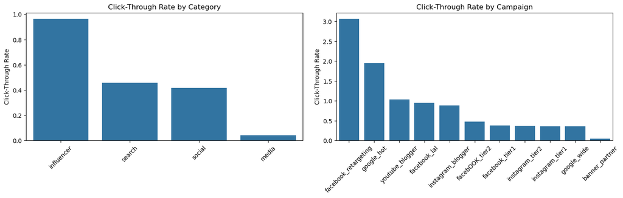

```python
# Calculate CTR for categories and campaigns

# For categories
categories_ctr = df.groupby('category', observed=True).agg(
    total_clicks = ('clicks', 'sum'),
    total_impressions = ('impressions', 'sum')
).reset_index()
categories_ctr['ctr'] = ((categories_ctr['total_clicks'] / categories_ctr['total_impressions']) * 100)
df = df.merge(categories_ctr[['category', 'ctr']], on='category', how='left')
df.rename(columns={'ctr': 'categories_ctr'}, inplace=True)

# For campaigns
campaigns_ctr = df.groupby('campaign_name', observed=True).agg(
    total_clicks = ('clicks', 'sum'),
    total_impressions = ('impressions', 'sum')
).reset_index()
campaigns_ctr['ctr'] = ((campaigns_ctr['total_clicks'] / campaigns_ctr['total_impressions']) * 100)
df = df.merge(campaigns_ctr[['campaign_name', 'ctr']], on='campaign_name', how='left')
df.rename(columns={'ctr': 'campaigns_ctr'}, inplace=True)

# Plot CTR for categories and campaigns

# Sort the df by CTR
sorted_categories_ctr = categories_ctr.sort_values(by='ctr', ascending=False)
sorted_campaigns_ctr = campaigns_ctr.sort_values(by='ctr', ascending=False)

# Create plots
fig, axes = plt.subplots(1, 2, figsize=(15,5))

sns.barplot(x='category', y='ctr', data=sorted_categories_ctr, ax=axes[0], order=sorted_categories_ctr['category'])
axes[0].set_title('Click-Through Rate by Category')
axes[0].set_ylabel('Click-Through Rate')
axes[0].set_xlabel('')

sns.barplot(x='campaign_name', y='ctr', data=sorted_campaigns_ctr, ax=axes[1], order=sorted_campaigns_ctr['campaign_name'])
axes[1].set_title('Click-Through Rate by Campaign')
axes[1].set_ylabel('Click-Through Rate')
axes[1].set_xlabel('')

# Rotate x-axis tick labels
for ax in axes:
    ax.tick_params(axis='x', rotation=45)

plt.tight_layout(pad=2)
plt.show()
```

##### Comments

- The highest click-through rate by category is about 0.95 (influencer) and the lowest one is about 0.05 (media)
- The highest click-through rate by campaign is about 3.0 (facebook_retargeting) and the lowest one is about 0.1 (banner_partner)

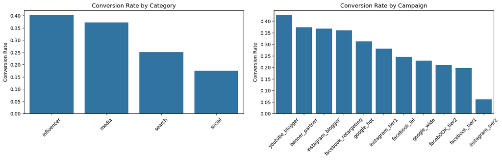

```python
# Calculate Conversion Rate for categories and campaigns

# For categories
categories_cr = df.groupby('category', observed=True).agg(
    total_orders = ('orders', 'sum'),
    total_clicks = ('clicks', 'sum')
).reset_index()
categories_cr['cr'] = ((categories_cr['total_orders'] / categories_ctr['total_clicks']) * 100)
df = df.merge(categories_cr[['category', 'cr']], on='category', how='left')
df.rename(columns={'cr': 'categories_cr'}, inplace=True)

# For campaigns
campaigns_cr = df.groupby('campaign_name', observed=True).agg(
    total_orders = ('orders', 'sum'),
    total_clicks = ('clicks', 'sum')
).reset_index()
campaigns_cr['cr'] = ((campaigns_cr['total_orders'] / campaigns_cr['total_clicks']) * 100)
df = df.merge(campaigns_cr[['campaign_name', 'cr']], on='campaign_name', how='left')
df.rename(columns={'cr': 'campaigns_cr'}, inplace=True)

# Plot Conversion Rate for categories and campaigns

# Sort the df by Conversion Rate
sorted_categories_cr = categories_cr.sort_values(by='cr', ascending=False)
sorted_campaigns_cr = campaigns_cr.sort_values(by='cr', ascending=False)

# Create plots
fig, axes = plt.subplots(1, 2, figsize=(15,5))

sns.barplot(x='category', y='cr', data=sorted_categories_cr, ax=axes[0], order=sorted_categories_cr['category'])
axes[0].set_title('Conversion Rate by Category')
axes[0].set_ylabel('Conversion Rate')
axes[0].set_xlabel('')

sns.barplot(x='campaign_name', y='cr', data=sorted_campaigns_cr, ax=axes[1], order=sorted_campaigns_cr['campaign_name'])
axes[1].set_title('Conversion Rate by Campaign')
axes[1].set_ylabel('Conversion Rate')
axes[1].set_xlabel('')

# Rotate x-axis tick labels
for ax in axes:
    ax.tick_params(axis='x', rotation=45)

plt.tight_layout(pad=2)
plt.show()
```

##### Comments

- The highest conversion rate by category is 0.4 (influencer) and the lowest one is 0.17 (social)
- The highest conversion rate by campaign is 0.41 (youtube_blogger) and the lowest one is 0.06 (instagram_tier2)

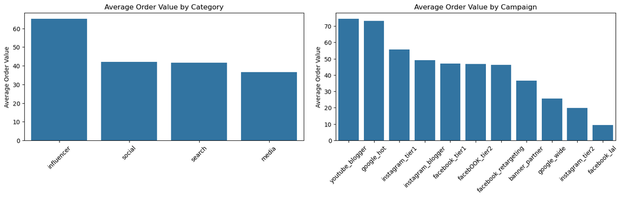

```python
# Calculate AOV for categories and campaigns

# For categories

categories_aov = df.groupby('category', observed=True).agg(
    total_revenue = ('revenue', 'sum'),
    total_orders = ('orders', 'sum')
).reset_index()
categories_aov['aov'] = (categories_aov['total_revenue'] / categories_aov['total_orders'])
df = df.merge(categories_aov[['category', 'aov']], on='category', how='left')
df.rename(columns={'aov': 'categories_aov'}, inplace=True)

# For campaigns

campaigns_aov = df.groupby('campaign_name', observed=True).agg(
    total_revenue = ('revenue', 'sum'),
    total_orders = ('orders', 'sum')
).reset_index()
campaigns_aov['aov'] = (campaigns_aov['total_revenue'] / campaigns_aov['total_orders'])
df = df.merge(campaigns_aov[['campaign_name', 'aov']], on='campaign_name', how='left')
df.rename(columns={'aov': 'campaigns_aov'}, inplace=True)

# Plot AOV for categories and campaigns

# Sort the df by AOV
sorted_categories_aov = categories_aov.sort_values(by='aov', ascending=False)
sorted_campaigns_aov = campaigns_aov.sort_values(by='aov', ascending=False)

# Create plots
fig, axes = plt.subplots(1, 2, figsize=(15,5))

sns.barplot(x='category', y='aov', data=sorted_categories_aov, ax=axes[0], order=sorted_categories_aov['category'])
axes[0].set_title('Average Order Value by Category')
axes[0].set_ylabel('Average Order Value')
axes[0].set_xlabel('')

sns.barplot(x='campaign_name', y='aov', data=sorted_campaigns_aov, ax=axes[1], order=sorted_campaigns_aov['campaign_name'])
axes[1].set_title('Average Order Value by Campaign')
axes[1].set_ylabel('Average Order Value')
axes[1].set_xlabel('')

# Rotate x-axis tick labels
for ax in axes:
    ax.tick_params(axis='x', rotation=45)

plt.tight_layout(pad=2)
plt.show()
```

## 3. Bulding Machine Learning Model to Predict the Number of Orders

### 3.1. Handle Outliers

Since the analysis is done, I will handle outliers using Z-scores to achieve a better performance of a machine learning model.

```python
# Calculate Z-scores for numerical features
numerical_columns = ['impressions', 'marketing_spend', 'clicks', 'leads', 'orders', 'revenue', 'categories_romi',
                     'campaigns_romi', 'categories_ctr', 'campaigns_ctr', 'categories_cr', 'campaigns_cr', 'categories_aov', 'campaigns_aov']
z_scores = np.abs(stats.zscore(df[numerical_columns]))

# Define a threshold of 3 for Z-scores
outlier_threshold = 3
df_clean = df[(z_scores < outlier_threshold).all(axis=1)]

# Check how many outliers were removed
print(f"Removed {len(df) - len(df_clean)} outliers")
```

```
Removed 19 outliers
```

### 3.2. Label Encoding

```python
# Initialise label encoder
label_encoder_categories = LabelEncoder()
label_encoder_campaigns = LabelEncoder()

# Make a copy of df_clean
df_clean = df_clean.copy()

# Encode campaigns and categories
df_clean['categories_encoded'] = label_encoder_categories.fit_transform(df_clean['category'])
df_clean['campaigns_encoded'] = label_encoder_campaigns.fit_transform(df_clean['campaign_name'])
```

### 3.3. Build Machine Learning Model to Predict Number of Orders (All Categories)

```python
# Define features (X) and target (y)
X = df_clean[['impressions', 'marketing_spend', 'clicks', 'leads', 'categories_ctr', 'campaigns_ctr', 'categories_encoded', 'campaigns_encoded']]
y = df_clean['orders']

# Train-test split and model training
X_train, X_test, y_train, y_test = train_test_split(X, y, test_size=0.2, random_state=42)
```

```python
# Initialise random forest regressor
rf_model = RandomForestRegressor(n_estimators=100, max_depth=10, random_state=42)

# Fit the model
rf_model.fit(X_train, y_train)

# Prediction
y_pred = rf_model.predict(X_test)
```

```python
# Calculate MSE and R2

mse = mean_squared_error(y_test, y_pred)
r2 = r2_score(y_test, y_pred)

print(f"Mean Squared Error (All Categories) is: {mse}")
print(f"R-Squared (All Categories) is: {r2}")
```

```
Mean Squared Error (All Categories) is: 109.29177423480517
R-Squared (All Categories) is: 0.8665367835729858
```

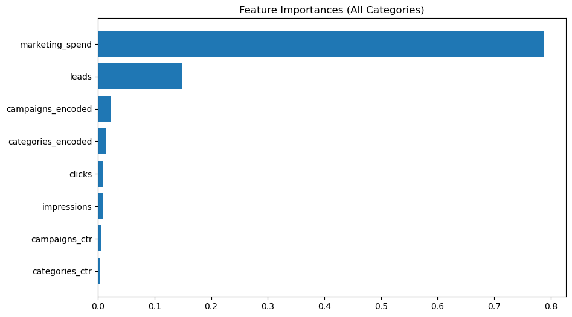

```python
# Feature importance from the model
feature_importances = rf_model.feature_importances_
features = X.columns

# Sort the feature importances in descending order and get the indices
indices = np.argsort(feature_importances)[::1]

# Plot feature importance
plt.figure(figsize=(10,6))
plt.barh(range(len(feature_importances)), feature_importances[indices], align='center')
plt.title('Feature Importances (All Categories)')
plt.yticks(range(len(feature_importances)), [features[i] for i in indices])
plt.show()
```

##### Comments

Since there is a significant difference between metrics in different categories, I will build models for each category and see if they perform better than a single model.

### 3.4. Build Machine Learning Model to Predict Number of Orders (Media Category)

```python
categories = df_clean['category'].unique()
```

```python
for category in categories:
    media_data = df_clean[df_clean['category'] == 'media']
```

```python
# Define features (X) and target (y)
X_media = media_data[['impressions', 'marketing_spend', 'clicks', 'leads', 'categories_ctr', 'campaigns_ctr', 'campaigns_encoded']]
y_media = media_data['orders']

# Train-test split and model training
X_train_media, X_test_media, y_train_media, y_test_media = train_test_split(X_media, y_media, test_size=0.2, random_state=42)
```

```python
# Initialise random forest regressor
rf_model_media = RandomForestRegressor(n_estimators=100, max_depth=10, random_state=42)

# Fit the model
rf_model_media.fit(X_train_media, y_train_media)

# Prediction
y_pred_media = rf_model_media.predict(X_test_media)
```

```python
# Calculate MSE and R2

mse_media = mean_squared_error(y_test_media, y_pred_media)
r2_media = r2_score(y_test_media, y_pred_media)

print(f"Mean Squared Error (Media Model) is: {mse_media}")
print(f"R-Squared (Media Model) is: {r2_media}")
```

```
Mean Squared Error (Media Model) is: 84.95482000000001
R-Squared (Media Model) is: 0.8789127423033067
```

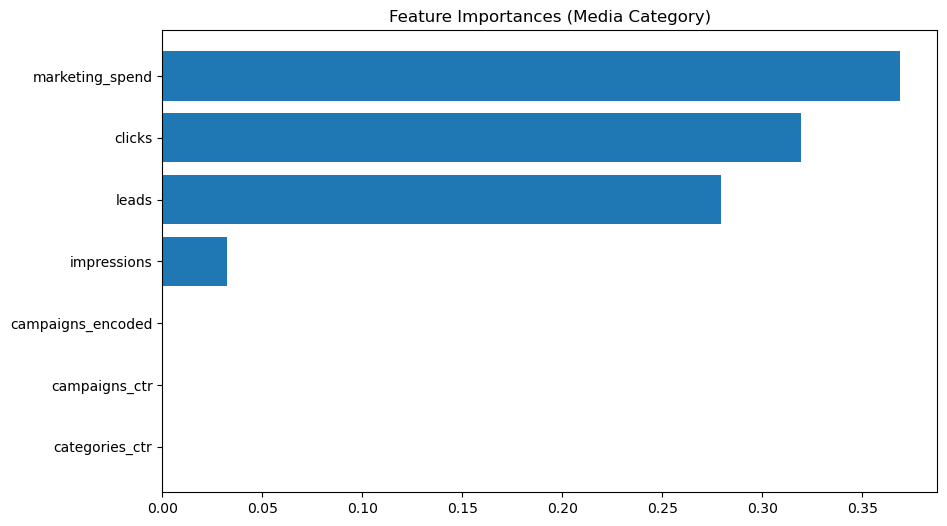

```python
# Feature importance from the model
feature_importances_media = rf_model_media.feature_importances_
features_media = X_media.columns

# Sort the feature importances in descending order and get the indices
indices_media = np.argsort(feature_importances_media)[::1]

# Plot feature importance
plt.figure(figsize=(10,6))
plt.barh(range(len(feature_importances_media)), feature_importances_media[indices_media], align='center')
plt.title('Feature Importances (Media Category)')
plt.yticks(range(len(feature_importances_media)), [features_media[i] for i in indices_media])
plt.show()
```

### 3.5. Build Machine Learning Model to Predict Number of Orders (Social Category)

```python
for category in categories:
    social_data = df_clean[df_clean['category'] == 'social']
```

```python
# Define features (X) and target (y)
X_social = social_data[['impressions', 'marketing_spend', 'clicks', 'leads', 'categories_ctr', 'campaigns_ctr', 'campaigns_encoded']]
y_social = social_data['orders']

# Train-test split and model training
X_train_social, X_test_social, y_train_social, y_test_social = train_test_split(X_social, y_social, test_size=0.2, random_state=42)
```

```python
# Initialise random forest regressor
rf_model_social = RandomForestRegressor(n_estimators=100, max_depth=10, random_state=42)

# Fit the model
rf_model_social.fit(X_train_social, y_train_social)

# Prediction
y_pred_social = rf_model_social.predict(X_test_social)
```

```python
# Calculate MSE and R2

mse_social = mean_squared_error(y_test_social, y_pred_social)
r2_social = r2_score(y_test_social, y_pred_social)

print(f"Mean Squared Error (Social Model) is: {mse_social}")
print(f"R-Squared (Social Model) is: {r2_social}")
```

```
Mean Squared Error (Social Model) is: 31.03914970151508
R-Squared (Social Model) is: 0.9261769962370654
```

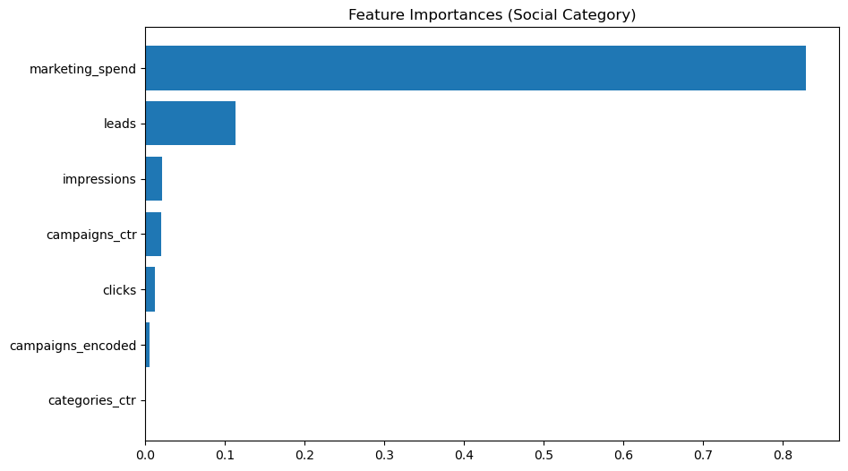

```python
# Feature importance from the model
feature_importances_social = rf_model_social.feature_importances_
features_social = X_social.columns

# Sort the feature importances in descending order and get the indices
indices_social = np.argsort(feature_importances_social)[::1]

# Plot feature importance
plt.figure(figsize=(10,6))
plt.barh(range(len(feature_importances_social)), feature_importances_social[indices_social], align='center')
plt.title('Feature Importances (Social Category)')
plt.yticks(range(len(feature_importances_social)), [features_social[i] for i in indices_social])
plt.show()
```

### 3.6. Build Machine Learning Model to Predict Number of Orders (Search Category)

```python
for category in categories:
    search_data = df_clean[df_clean['category'] == 'search']
```

```python
# Define features (X) and target (y)
X_search = search_data[['impressions', 'marketing_spend', 'clicks', 'leads', 'categories_ctr', 'campaigns_ctr', 'campaigns_encoded']]
y_search = search_data['orders']

# Train-test split and model training
X_train_search, X_test_search, y_train_search, y_test_search = train_test_split(X_search, y_search, test_size=0.2, random_state=42)
```

```python
# Initialise random forest regressor
rf_model_search = RandomForestRegressor(n_estimators=100, max_depth=10, random_state=42)

# Fit the model
rf_model_search.fit(X_train_search, y_train_search)

# Prediction
y_pred_search = rf_model_search.predict(X_test_search)
```

```python
# Calculate MSE and R2

mse_search = mean_squared_error(y_test_search, y_pred_search)
r2_search = r2_score(y_test_search, y_pred_search)

print(f"Mean Squared Error (Search Model) is: {mse_search}")
print(f"R-Squared (Search Model) is: {r2_search}")
```

```
Mean Squared Error (Search Model) is: 5.474908333333333
R-Squared (Search Model) is: 0.962256472615856
```

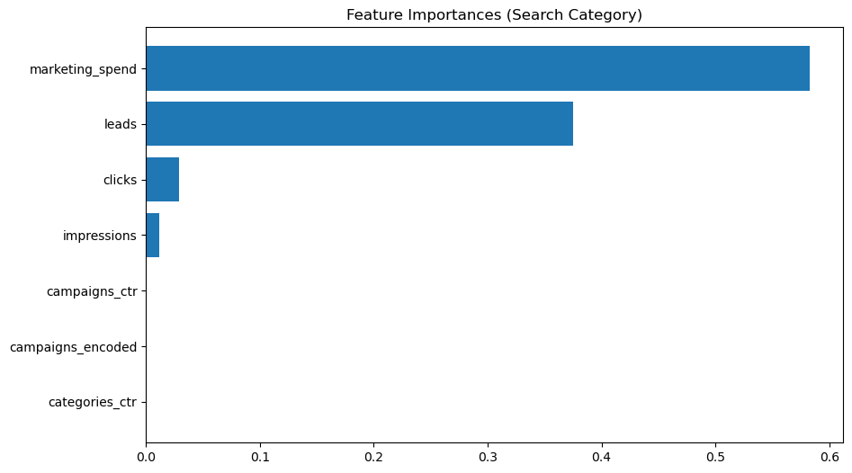

```python
# Feature importance from the model
feature_importances_search = rf_model_search.feature_importances_
features_search = X_search.columns

# Sort the feature importances in descending order and get the indices
indices_search = np.argsort(feature_importances_search)[::1]

# Plot feature importance
plt.figure(figsize=(10,6))
plt.barh(range(len(feature_importances_search)), feature_importances_search[indices_search], align='center')
plt.title('Feature Importances (Search Category)')
plt.yticks(range(len(feature_importances_search)), [features_search[i] for i in indices_search])
plt.show()
```

### 3.7. Build Machine Learning Model to Predict Number of Orders (Influencer Category)

```python
for category in categories:
    influencer_data = df_clean[df_clean['category'] == 'influencer']
```

```python
# Define features (X) and target (y)
X_influencer = influencer_data[['impressions', 'marketing_spend', 'clicks', 'leads', 'categories_ctr', 'campaigns_ctr', 'campaigns_encoded']]
y_influencer = influencer_data['orders']

# Train-test split and model training
X_train_influencer, X_test_influencer, y_train_influencer, y_test_influencer = train_test_split(X_influencer, y_influencer,
                                                                                                test_size=0.2, random_state=42)
```

```python
# Initialise random forest regressor
rf_model_influencer = RandomForestRegressor(n_estimators=100, max_depth=10, random_state=42)

# Fit the model
rf_model_influencer.fit(X_train_influencer, y_train_influencer)

# Prediction
y_pred_influencer = rf_model_influencer.predict(X_test_influencer)
```

```python
# Calculate MSE and R2

mse_influencer = mean_squared_error(y_test_influencer, y_pred_influencer)
r2_influencer = r2_score(y_test_influencer, y_pred_influencer)

print(f"Mean Squared Error (Influencer Model) is: {mse_influencer}")
print(f"R-Squared (Influencer Model) is: {r2_influencer}")
```

```
Mean Squared Error (Influencer Model) is: 66.36980999999999
R-Squared (Influencer Model) is: 0.9581128249468284
```

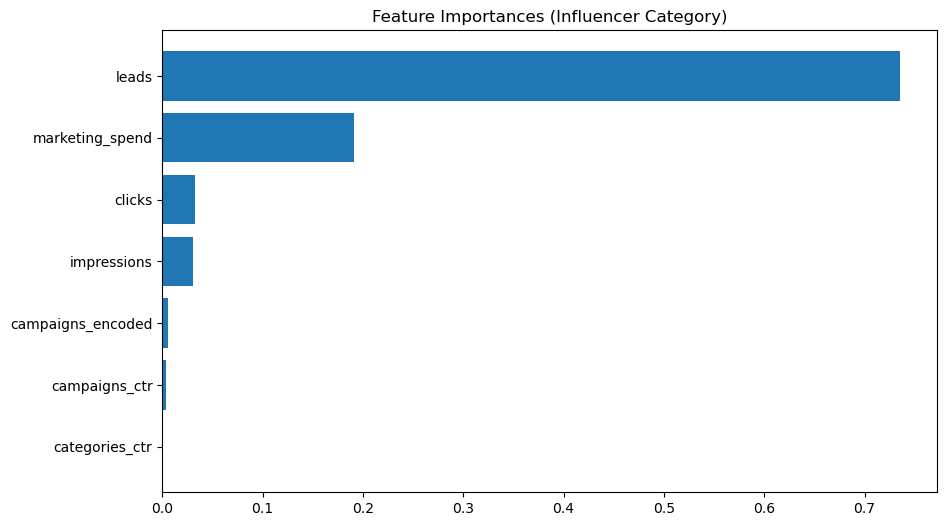

```python
# Feature importance from the model
feature_importances_influencer = rf_model_influencer.feature_importances_
features_influencer = X_influencer.columns

# Sort the feature importances in descending order and get the indices
indices_influencer = np.argsort(feature_importances_influencer)[::1]

# Plot feature importance
plt.figure(figsize=(10,6))
plt.barh(range(len(feature_importances_influencer)), feature_importances_influencer[indices_influencer], align='center')
plt.title('Feature Importances (Influencer Category)')
plt.yticks(range(len(feature_importances_influencer)), [features_influencer[i] for i in indices_influencer])
plt.show()
```

### 3.8. Evaluating and Improving All Models

```python
# Cross-validation

cross_val_scores = cross_val_score (rf_model, X, y, cv=5, scoring='neg_mean_squared_error')
cross_val_scores_media = cross_val_score (rf_model_media, X_media, y_media, cv=5, scoring='neg_mean_squared_error')
cross_val_scores_social = cross_val_score (rf_model_social, X_social, y_social, cv=5, scoring='neg_mean_squared_error')
cross_val_scores_search = cross_val_score (rf_model_search, X_search, y_search, cv=5, scoring='neg_mean_squared_error')
cross_val_scores_influencer = cross_val_score (rf_model_influencer, X_influencer, y_influencer, cv=5, scoring='neg_mean_squared_error')
print(f"Cross-Validated MSE (All Categories) is: ", -cross_val_scores.mean())
print(f"Cross-Validated MSE (Media Category) is: ", -cross_val_scores_media.mean())
print(f"Cross-Validated MSE (Social Category) is: ", -cross_val_scores_social.mean())
print(f"Cross-Validated MSE (Search Category) is: ", -cross_val_scores_search.mean())
print(f"Cross-Validated MSE (Influencer Category) is: ", -cross_val_scores_influencer.mean())
```

```
Cross-Validated MSE (All Categories) is:  77.80616327009832
Cross-Validated MSE (Media Category) is:  101.384545
Cross-Validated MSE (Social Category) is:  64.70418370601212
Cross-Validated MSE (Search Category) is:  29.988619999999997
Cross-Validated MSE (Influencer Category) is:  88.56588155555558
```

##### Comments

Search Category is performing very well, but others models can be improved. I will focus on tuning hyperparameters. Hyperparameter tuning is the process of finding the best combination of hyperparameters that optimizes model performance.

I will use RandomizedSearchCV, which:

- Randomly searches across a specified range of hyperparameters.
- Evaluates different combinations using cross-validation.
- Returns the best combination of hyperparameters based on a scoring metric (e.g., MSE, R²).

#### 3.8.1. Tuning Hyperparameters (All Categories Model)

```python
# Define the hyperparameter space for RandomizedSearchCV
param_dist = {
    'n_estimators': randint(100, 1000),        # Number of trees in the forest
    'max_depth': randint(1, 20),               # Max depth of each tree
    'min_samples_split': randint(2, 20),       # Minimum samples required to split a node
    'min_samples_leaf': randint(1, 20),        # Minimum samples required to be a leaf
    'max_features': ['sqrt', 'log2', None]     # Number of features to consider for splitting
}

# Initialise random forest regressor
rf_model_best = RandomForestRegressor(random_state=42)

# Set up RandomizedSearchCV
random_search = RandomizedSearchCV(
    rf_model_best,          # RandomForestRegressor model
    param_distributions=param_dist,       # Hyperparameter space defined earlier
    n_iter=100,        # Number of random combinations of hyperparameters to test
    cv=5,              # Number of cross-validation folds to evaluate each combination
    verbose=1,         # Verbosity level
    n_jobs=-1,         # Use all available CPU cores to speed up training
    random_state=42    # For reproducibility
)

# Fit the model with RandomizedSearchCV and search for the best parameters
random_search.fit(X_train, y_train)

# Access the best model from the search
rf_model_best = random_search.best_estimator_

# Output the best hyperparameters
print(f"Best parameters found (All Categories) are: {random_search.best_params_}")

# Predict using the best model
y_pred = random_search.best_estimator_.predict(X_test)

# Calculate MSE and R-squared
mse_best = mean_squared_error(y_test, y_pred)
r2_best = r2_score(y_test, y_pred)

# Perform cross-validation with the best model to evaluate generalization
cross_val_scores_best = cross_val_score(random_search.best_estimator_, X_train, y_train, cv=5, scoring='neg_mean_squared_error')
```

```
Fitting 5 folds for each of 100 candidates, totalling 500 fits
Best parameters found (All Categories) are: {'max_depth': 5, 'max_features': 'sqrt', 'min_samples_leaf': 1, 'min_samples_split': 3, 'n_estimators': 152}
```

```python
# Compare the model's performance before and after tuning
print(f"Mean Squared Error After Tuning (All Categories) is: {mse_best:.2f}\nMean Squared Error Before Tuning (All Categories) is: {mse:.2f}")
print(f"R-Squared After Tuning (All Categories) is: {r2_best:.2f}\nR-Squared Before Tuning (All Categories) is: {r2:.2f}")
print(f"Cross-Validated MSE After Tuning (All Categories) is: {-cross_val_scores_best.mean():.2f}\nCross-Validated MSE Before Tuning (All Categories) is: {-cross_val_scores.mean():.2f}")
```

```
Mean Squared Error After Tuning (All Categories) is: 56.27
Mean Squared Error Before Tuning (All Categories) is: 109.29
R-Squared After Tuning (All Categories) is: 0.93
R-Squared Before Tuning (All Categories) is: 0.87
Cross-Validated MSE After Tuning (All Categories) is: 95.00
Cross-Validated MSE Before Tuning (All Categories) is: 77.81
```

##### Comments

After tuning, MSE and R-squared improved; however, cross-validation MSE became worse. To fix this, I will try to increase the number of folds to get a more representative estimate of performance.

```python
# Craete a KFold cross-validator
kf = KFold(n_splits=10, shuffle=True, random_state=42)

# Define the hyperparameter space for RandomizedSearchCV
param_dist = {
    'n_estimators': randint(100, 1000),        # Number of trees in the forest
    'max_depth': randint(1, 20),               # Max depth of each tree
    'min_samples_split': randint(2, 20),       # Minimum samples required to split a node
    'min_samples_leaf': randint(1, 20),        # Minimum samples required to be a leaf
    'max_features': ['sqrt', 'log2', None]     # Number of features to consider for splitting
}

# Initialise random forest regressor
rf_model_best_2 = RandomForestRegressor(random_state=42)

# Set up RandomizedSearchCV
random_search = RandomizedSearchCV(
    rf_model_best_2,          # RandomForestRegressor model
    param_distributions=param_dist,       # Hyperparameter space defined earlier
    n_iter=100,        # Number of random combinations of hyperparameters to test
    cv=kf,              # Number of cross-validation folds to evaluate each combination
    verbose=1,         # Verbosity level
    n_jobs=-1,         # Use all available CPU cores to speed up training
    random_state=42    # For reproducibility
)

# Fit the model with RandomizedSearchCV and search for the best parameters
random_search.fit(X_train, y_train)

# Access the best model from the search
rf_model_best_2 = random_search.best_estimator_

# Output the best hyperparameters
print(f"Best parameters found (All Categories) are: {random_search.best_params_}")

# Predict using the best model
y_pred = random_search.best_estimator_.predict(X_test)

# Calculate MSE and R-squared
mse_best_2 = mean_squared_error(y_test, y_pred)
r2_best_2 = r2_score(y_test, y_pred)

# Perform cross-validation with the best model to evaluate generalization
cross_val_scores_best_2 = cross_val_score(random_search.best_estimator_, X_train, y_train, cv=5, scoring='neg_mean_squared_error')
```

```
Fitting 10 folds for each of 100 candidates, totalling 1000 fits
Best parameters found (All Categories) are: {'max_depth': 5, 'max_features': 'sqrt', 'min_samples_leaf': 1, 'min_samples_split': 3, 'n_estimators': 152}
```

```python
# Compare the model's performance before and after tuning / using KFold cross-validator
print(f"Mean Squared Error After Using KFold cross-validator (All Categories) is: {mse_best_2:.2f}\nMean Squared Error After Tuning (All Categories) is: {mse_best:.2f}\nMean Squared Error Before Tuning (All Categories) is: {mse:.2f}")
print(f"R-Squared After Using KFold cross-validator (All Categories) is: {r2_best_2:.2f}\nR-Squared After Tuning (All Categories) is: {r2_best:.2f}\nR-Squared Before Tuning (All Categories) is: {r2:.2f}")
print(f"Cross-Validated MSE After Using KFold cross-validator (All Categories) is: {-cross_val_scores_best_2.mean():.2f}\nCross-Validated MSE After Tuning (All Categories) is: {-cross_val_scores_best.mean():.2f}\nCross-Validated MSE Before Tuning (All Categories) is: {-cross_val_scores.mean():.2f}")
```

```
Mean Squared Error After Using KFold cross-validator (All Categories) is: 56.27
Mean Squared Error After Tuning (All Categories) is: 56.27
Mean Squared Error Before Tuning (All Categories) is: 109.29
R-Squared After Using KFold cross-validator (All Categories) is: 0.93
R-Squared After Tuning (All Categories) is: 0.93
R-Squared Before Tuning (All Categories) is: 0.87
Cross-Validated MSE After Using KFold cross-validator (All Categories) is: 95.00
Cross-Validated MSE After Tuning (All Categories) is: 95.00
Cross-Validated MSE Before Tuning (All Categories) is: 77.81
```

##### Comments

- Initial model: MSE = 109.29; R2 = 0.87; Cross-Validated MSE = 77.81
- After tuning: MSE = 56.27; R2 = 0.93; Cross-Validated MSE = 95.00
- After KFold cross-validator = 56.27; R2 = 0.93; Cross-Validated MSE = 95.00

Based on these results, I can conclude that the best model is the one after tuning because it got significantly improved MSE and R2. Cross-Validated MSE after tuning because slightly worse, but not significantly worse, it is still acceptable. Using KFold cross-validator did not change the model at all - probably, because my data set is not large enough. Hence, I will not be using KFold cross-validator for individual models because those models will have even less data (since they represent individual categories).

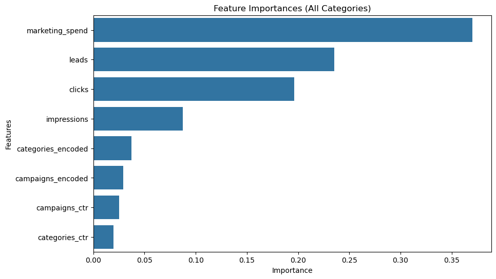

```python
feature_names_best = X.columns

# Get feature importances from the model
importances_best = rf_model_best.feature_importances_

# Create a df with feature names and their corresponding importances
feature_importance_best_df = pd.DataFrame({
    'Feature': feature_names_best,
    'Importance': importances_best
})

# Sort the df by importance in descending order
feature_importance_best_df = feature_importance_best_df.sort_values(by='Importance', ascending=False)

# Plot
plt.figure(figsize=(10, 6))
sns.barplot(x='Importance', y='Feature', data=feature_importance_best_df)
plt.title("Feature Importances (All Categories)")
plt.xlabel("Importance")
plt.ylabel("Features")
plt.show()
```

#### 3.8.2. Tuning Hyperparameters (Influencer Model)

```python
# Define the hyperparameter space for RandomizedSearchCV
param_dist = {
    'n_estimators': randint(100, 1000),        # Number of trees in the forest
    'max_depth': randint(1, 20),               # Max depth of each tree
    'min_samples_split': randint(2, 20),       # Minimum samples required to split a node
    'min_samples_leaf': randint(1, 20),        # Minimum samples required to be a leaf
    'max_features': ['sqrt', 'log2', None]     # Number of features to consider for splitting
}

# Initialise random forest regressor
rf_model_influencer_best = RandomForestRegressor(random_state=42)

# Set up RandomizedSearchCV
random_search = RandomizedSearchCV(
    rf_model_influencer_best,          # RandomForestRegressor model
    param_distributions=param_dist,       # Hyperparameter space defined earlier
    n_iter=100,        # Number of random combinations of hyperparameters to test
    cv=5,              # Number of cross-validation folds to evaluate each combination
    verbose=1,         # Verbosity level
    n_jobs=-1,         # Use all available CPU cores to speed up training
    random_state=42    # For reproducibility
)

# Fit the model with RandomizedSearchCV and search for the best parameters
random_search.fit(X_train_influencer, y_train_influencer)

# Access the best model from the search
rf_model_influencer_best = random_search.best_estimator_

# Output the best hyperparameters
print(f"Best parameters found (Influencer Model) are: {random_search.best_params_}")

# Predict using the best model
y_pred_influencer = random_search.best_estimator_.predict(X_test_influencer)

# Calculate MSE and R-squared
mse_best_influencer = mean_squared_error(y_test_influencer, y_pred_influencer)
r2_best_influencer = r2_score(y_test_influencer, y_pred_influencer)

# Perform cross-validation with the best model to evaluate generalization
cross_val_scores_best_influencer = cross_val_score(random_search.best_estimator_, X_train_influencer, y_train_influencer, cv=5, scoring='neg_mean_squared_error')
```

```
Fitting 5 folds for each of 100 candidates, totalling 500 fits
Best parameters found (Influencer Model) are: {'max_depth': 3, 'max_features': None, 'min_samples_leaf': 1, 'min_samples_split': 6, 'n_estimators': 589}
```

```python
# Compare the model's performance before and after tuning
print(f"Mean Squared Error After Tuning (Influencer Model) is: {mse_best_influencer:.2f}\nMean Squared Error Before Tuning (Influencer Model) is: {mse_influencer:.2f}")
print(f"R-Squared After Tuning (Influencer Model) is: {r2_best_influencer:.2f}\nR-Squared Before Tuning (Influencer Model) is: {r2_influencer:.2f}")
print(f"Cross-Validated MSE After Tuning (Influencer Model) is: {-cross_val_scores_best_influencer.mean():.2f}\nCross-Validated MSE Before Tuning (Influencer Model) is: {-cross_val_scores_influencer.mean():.2f}")
```

```
Mean Squared Error After Tuning (Influencer Model) is: 39.40
Mean Squared Error Before Tuning (Influencer Model) is: 66.37
R-Squared After Tuning (Influencer Model) is: 0.98
R-Squared Before Tuning (Influencer Model) is: 0.96
Cross-Validated MSE After Tuning (Influencer Model) is: 128.25
Cross-Validated MSE Before Tuning (Influencer Model) is: 88.57
```

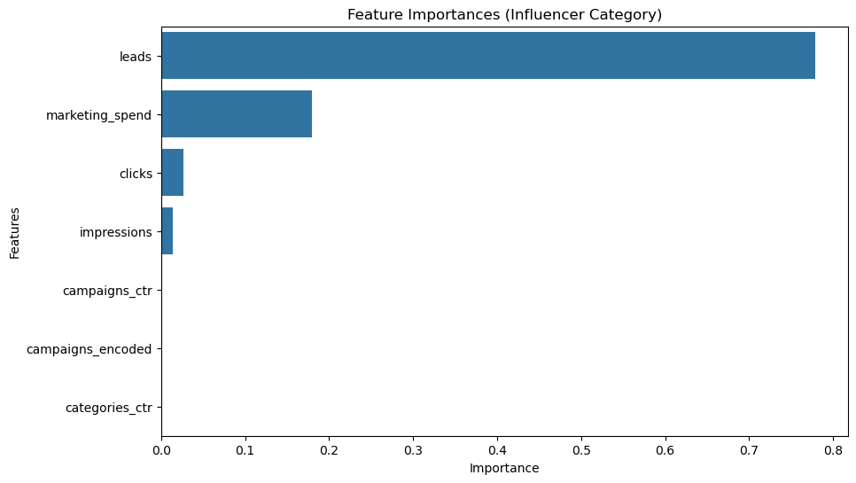

```python
feature_names_influencer_best = X_influencer.columns

# Get feature importances from the model
importances_influencer_best = rf_model_influencer_best.feature_importances_

# Create a df with feature names and their corresponding importances
feature_importance_influencer_best_df = pd.DataFrame({
    'Feature': feature_names_influencer_best,
    'Importance': importances_influencer_best
})

# Sort the df by importance in descending order
feature_importance_influencer_best_df = feature_importance_influencer_best_df.sort_values(by='Importance', ascending=False)

# Plot
plt.figure(figsize=(10, 6))
sns.barplot(x='Importance', y='Feature', data=feature_importance_influencer_best_df)
plt.title("Feature Importances (Influencer Category)")
plt.xlabel("Importance")
plt.ylabel("Features")
plt.show()
```

#### 3.8.3. Tuning Hyperparameters (Search Model)

```python
# Define the hyperparameter space for RandomizedSearchCV
param_dist = {
    'n_estimators': randint(100, 1000),        # Number of trees in the forest
    'max_depth': randint(1, 20),               # Max depth of each tree
    'min_samples_split': randint(2, 20),       # Minimum samples required to split a node
    'min_samples_leaf': randint(1, 20),        # Minimum samples required to be a leaf
    'max_features': ['sqrt', 'log2', None]     # Number of features to consider for splitting
}

# Initialise random forest regressor
rf_model_search_best = RandomForestRegressor(random_state=42)

# Set up RandomizedSearchCV
random_search = RandomizedSearchCV(
    rf_model_search_best,          # RandomForestRegressor model
    param_distributions=param_dist,       # Hyperparameter space defined earlier
    n_iter=100,        # Number of random combinations of hyperparameters to test
    cv=5,              # Number of cross-validation folds to evaluate each combination
    verbose=1,         # Verbosity level
    n_jobs=-1,         # Use all available CPU cores to speed up training
    random_state=42    # For reproducibility
)

# Fit the model with RandomizedSearchCV and search for the best parameters
random_search.fit(X_train_search, y_train_search)

# Access the best model from the search
rf_model_search_best = random_search.best_estimator_

# Output the best hyperparameters
print(f"Best parameters found (Search Model) are: {random_search.best_params_}")

# Predict using the best model
y_pred_search = random_search.best_estimator_.predict(X_test_search)

# Calculate MSE and R-squared
mse_best_search = mean_squared_error(y_test_search, y_pred_search)
r2_best_search = r2_score(y_test_search, y_pred_search)

# Perform cross-validation with the best model to evaluate generalization
cross_val_scores_best_search = cross_val_score(random_search.best_estimator_, X_train_search, y_train_search, cv=5, scoring='neg_mean_squared_error')
```

```
Fitting 5 folds for each of 100 candidates, totalling 500 fits
Best parameters found (Search Model) are: {'max_depth': 5, 'max_features': 'sqrt', 'min_samples_leaf': 1, 'min_samples_split': 3, 'n_estimators': 152}
```

```python
# Compare the model's performance before and after tuning
print(f"Mean Squared Error After Tuning (Search Model) is: {mse_best_search:.2f}\nMean Squared Error Before Tuning (Search Model) is: {mse_search:.2f}")
print(f"R-Squared After Tuning (Search Model) is: {r2_best_search:.2f}\nR-Squared Before Tuning (Search Model) is: {r2_search:.2f}")
print(f"Cross-Validated MSE After Tuning (Search Model) is: {-cross_val_scores_best_search.mean():.2f}\nCross-Validated MSE Before Tuning (Search Model) is: {-cross_val_scores_search.mean():.2f}")
```

```
Mean Squared Error After Tuning (Search Model) is: 15.72
Mean Squared Error Before Tuning (Search Model) is: 5.47
R-Squared After Tuning (Search Model) is: 0.89
R-Squared Before Tuning (Search Model) is: 0.96
Cross-Validated MSE After Tuning (Search Model) is: 51.78
Cross-Validated MSE Before Tuning (Search Model) is: 29.99
```

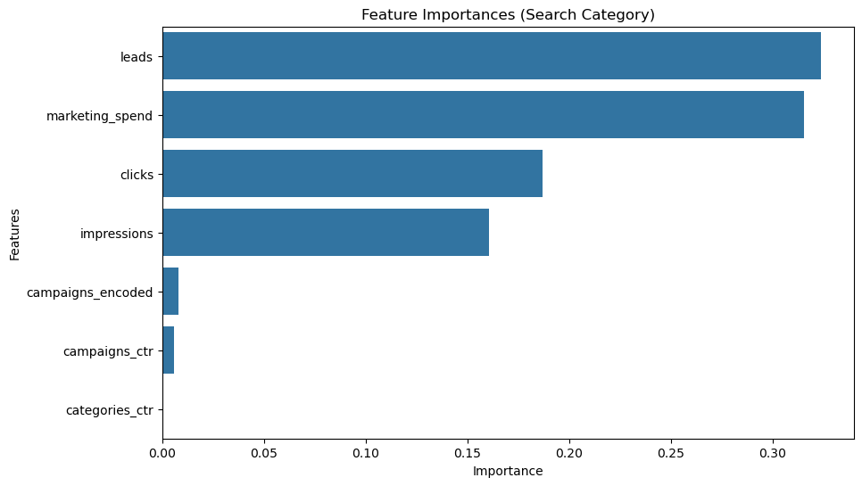

```python
feature_names_search_best = X_search.columns

# Get feature importances from the model
importances_search_best = rf_model_search_best.feature_importances_

# Create a df with feature names and their corresponding importances
feature_importance_search_best_df = pd.DataFrame({
    'Feature': feature_names_search_best,
    'Importance': importances_search_best
})

# Sort the df by importance in descending order
feature_importance_search_best_df = feature_importance_search_best_df.sort_values(by='Importance', ascending=False)

# Plot
plt.figure(figsize=(10, 6))
sns.barplot(x='Importance', y='Feature', data=feature_importance_search_best_df)
plt.title("Feature Importances (Search Category)")
plt.xlabel("Importance")
plt.ylabel("Features")
plt.show()
```

#### 3.8.4. Tuning Hyperparameters (Social Model)

```python
# Define the hyperparameter space for RandomizedSearchCV
param_dist = {
    'n_estimators': randint(100, 1000),        # Number of trees in the forest
    'max_depth': randint(1, 20),               # Max depth of each tree
    'min_samples_split': randint(2, 20),       # Minimum samples required to split a node
    'min_samples_leaf': randint(1, 20),        # Minimum samples required to be a leaf
    'max_features': ['sqrt', 'log2', None]     # Number of features to consider for splitting
}

# Initialise random forest regressor
rf_model_social_best = RandomForestRegressor(random_state=42)

# Set up RandomizedSearchCV
random_social = RandomizedSearchCV(
    rf_model_social_best,          # RandomForestRegressor model
    param_distributions=param_dist,       # Hyperparameter space defined earlier
    n_iter=100,        # Number of random combinations of hyperparameters to test
    cv=5,              # Number of cross-validation folds to evaluate each combination
    verbose=1,         # Verbosity level
    n_jobs=-1,         # Use all available CPU cores to speed up training
    random_state=42    # For reproducibility
)

# Fit the model with RandomizedSearchCV and search for the best parameters
random_search.fit(X_train_social, y_train_social)

# Access the best model from the search
rf_model_social_best = random_search.best_estimator_

# Output the best hyperparameters
print(f"Best parameters found (Social Model) are: {random_search.best_params_}")

# Predict using the best model
y_pred_social = random_search.best_estimator_.predict(X_test_social)

# Calculate MSE and R-squared
mse_best_social = mean_squared_error(y_test_social, y_pred_social)
r2_best_social = r2_score(y_test_social, y_pred_social)

# Perform cross-validation with the best model to evaluate generalization
cross_val_scores_best_social = cross_val_score(random_search.best_estimator_, X_train_social, y_train_social, cv=5, scoring='neg_mean_squared_error')
```

```
Fitting 5 folds for each of 100 candidates, totalling 500 fits
Best parameters found (Social Model) are: {'max_depth': 3, 'max_features': None, 'min_samples_leaf': 1, 'min_samples_split': 6, 'n_estimators': 589}
```

```python
# Compare the model's performance before and after tuning
print(f"Mean Squared Error After Tuning (Social Model) is: {mse_best_social:.2f}\nMean Squared Error Before Tuning (Social Model) is: {mse_social:.2f}")
print(f"R-Squared After Tuning (Social Model) is: {r2_best_social:.2f}\nR-Squared Before Tuning (Social Model) is: {r2_social:.2f}")
print(f"Cross-Validated MSE After Tuning (Social Model) is: {-cross_val_scores_best_social.mean():.2f}\nCross-Validated MSE Before Tuning (Social Model) is: {-cross_val_scores_social.mean():.2f}")
```

```
Mean Squared Error After Tuning (Social Model) is: 31.23
Mean Squared Error Before Tuning (Social Model) is: 31.04
R-Squared After Tuning (Social Model) is: 0.93
R-Squared Before Tuning (Social Model) is: 0.93
Cross-Validated MSE After Tuning (Social Model) is: 67.70
Cross-Validated MSE Before Tuning (Social Model) is: 64.70
```

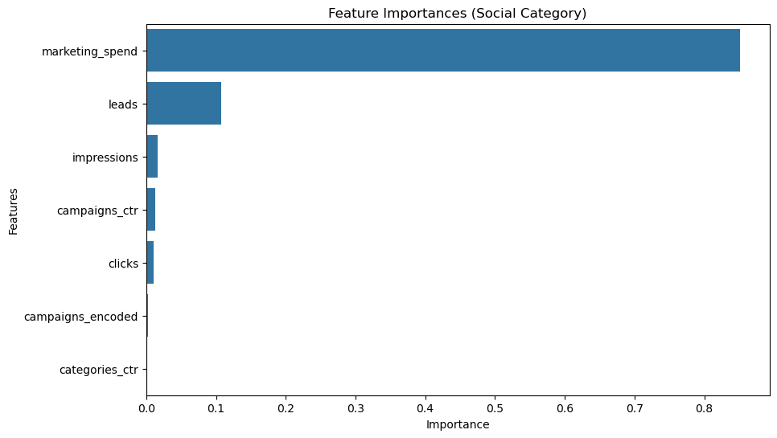

```python
feature_names_social_best = X_social.columns

# Get feature importances from the model
importances_social_best = rf_model_social_best.feature_importances_

# Create a df with feature names and their corresponding importances
feature_importance_social_best_df = pd.DataFrame({
    'Feature': feature_names_social_best,
    'Importance': importances_social_best
})

# Sort the df by importance in descending order
feature_importance_social_best_df = feature_importance_social_best_df.sort_values(by='Importance', ascending=False)

# Plot
plt.figure(figsize=(10, 6))
sns.barplot(x='Importance', y='Feature', data=feature_importance_social_best_df)
plt.title("Feature Importances (Social Category)")
plt.xlabel("Importance")
plt.ylabel("Features")
plt.show()
```

#### 3.8.5. Tuning Hyperparameters (Media Model)

```python
# Define the hyperparameter space for RandomizedSearchCV
param_dist = {
    'n_estimators': randint(100, 1000),        # Number of trees in the forest
    'max_depth': randint(1, 20),               # Max depth of each tree
    'min_samples_split': randint(2, 20),       # Minimum samples required to split a node
    'min_samples_leaf': randint(1, 20),        # Minimum samples required to be a leaf
    'max_features': ['sqrt', 'log2', None]     # Number of features to consider for splitting
}

# Initialise random forest regressor
rf_model_media_best = RandomForestRegressor(random_state=42)

# Set up RandomizedSearchCV
random_media = RandomizedSearchCV(
    rf_model_media_best,          # RandomForestRegressor model
    param_distributions=param_dist,       # Hyperparameter space defined earlier
    n_iter=100,        # Number of random combinations of hyperparameters to test
    cv=5,              # Number of cross-validation folds to evaluate each combination
    verbose=1,         # Verbosity level
    n_jobs=-1,         # Use all available CPU cores to speed up training
    random_state=42    # For reproducibility
)

# Fit the model with RandomizedSearchCV and search for the best parameters
random_search.fit(X_train_media, y_train_media)

# Access the best model from the search
rf_model_media_best = random_search.best_estimator_

# Output the best hyperparameters
print(f"Best parameters found (Media Model) are: {random_search.best_params_}")

# Predict using the best model
y_pred_media = random_search.best_estimator_.predict(X_test_media)

# Calculate MSE and R-squared
mse_best_media = mean_squared_error(y_test_media, y_pred_media)
r2_best_media = r2_score(y_test_media, y_pred_media)

# Perform cross-validation with the best model to evaluate generalization
cross_val_scores_best_media = cross_val_score(random_search.best_estimator_, X_train_media, y_train_media, cv=5, scoring='neg_mean_squared_error')
```

```
Fitting 5 folds for each of 100 candidates, totalling 500 fits
Best parameters found (Media Model) are: {'max_depth': 5, 'max_features': 'sqrt', 'min_samples_leaf': 1, 'min_samples_split': 3, 'n_estimators': 152}
```

```python
# Compare the model's performance before and after tuning
print(f"Mean Squared Error After Tuning (Media Model) is: {mse_best_media:.2f}\nMean Squared Error Before Tuning (Media Model) is: {mse_media:.2f}")
print(f"R-Squared After Tuning (Media Model) is: {r2_best_media:.2f}\nR-Squared Before Tuning (Media Model) is: {r2_media:.2f}")
print(f"Cross-Validated MSE After Tuning (Media Model) is: {-cross_val_scores_best_media.mean():.2f}\nCross-Validated MSE Before Tuning (Media Model) is: {-cross_val_scores_media.mean():.2f}")
```

```
Mean Squared Error After Tuning (Media Model) is: 90.56
Mean Squared Error Before Tuning (Media Model) is: 84.95
R-Squared After Tuning (Media Model) is: 0.87
R-Squared Before Tuning (Media Model) is: 0.88
Cross-Validated MSE After Tuning (Media Model) is: 190.72
Cross-Validated MSE Before Tuning (Media Model) is: 101.38
```

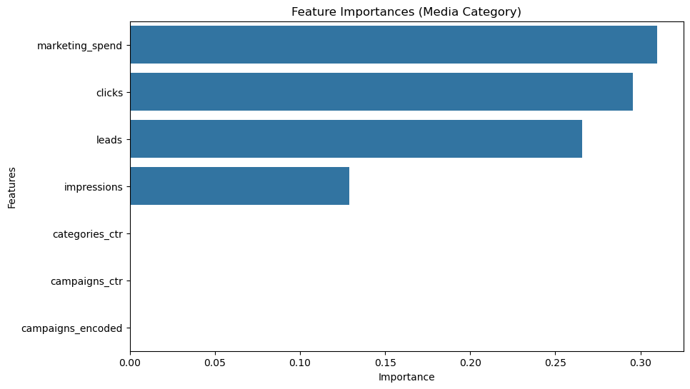

```python
feature_names_media_best = X_media.columns

# Get feature importances from the model
importances_media_best = rf_model_media_best.feature_importances_

# Create a df with feature names and their corresponding importances
feature_importance_media_best_df = pd.DataFrame({
    'Feature': feature_names_media_best,
    'Importance': importances_media_best
})

# Sort the df by importance in descending order
feature_importance_media_best_df = feature_importance_media_best_df.sort_values(by='Importance', ascending=False)

# Plot
plt.figure(figsize=(10, 6))
sns.barplot(x='Importance', y='Feature', data=feature_importance_media_best_df)
plt.title("Feature Importances (Media Category)")
plt.xlabel("Importance")
plt.ylabel("Features")
plt.show()
```

#### 3.8.6. Evaluating All Models

```python
models = ['All Categories', 'Media', 'Search', 'Social', 'Influencer']
mse_before_tuning = [mse, mse_media, mse_search, mse_social, mse_influencer]
mse_after_tuning = [mse_best, mse_best_media, mse_best_search, mse_best_social, mse_best_influencer]

# Format data
def format_2f(value):
    return f"{value:.2f}"

# Create a table
table = tabulate(zip(models, map(format_2f, mse_before_tuning), map(format_2f, mse_after_tuning)),
                 headers=['Model', 'MSE Before Tuning', 'MSE After Tuning'],
                 tablefmt='pretty')
print(table)
```

```
+----------------+-------------------+------------------+
|     Model      | MSE Before Tuning | MSE After Tuning |
+----------------+-------------------+------------------+
| All Categories |      109.29       |      56.27       |
|     Media      |       84.95       |      90.56       |
|     Search     |       5.47        |      15.72       |
|     Social     |       31.04       |      31.23       |
|   Influencer   |       66.37       |      39.40       |
+----------------+-------------------+------------------+
```

##### Comments

- The best MSE: Search Model before tuning. Also: Search Model after tuning, All Categories after tuning, Social Model before and after tuning, Influencer Model after tuning
- The All Categories and Influencer models' MSEs significantly improved after tuning
- Social Model's MSE became insignificantly worse (by 0.19)
- Media and Search Models' MSEs became worse after tuning

```python
models = ['All Categories', 'Media', 'Search', 'Social', 'Influencer']
r2_before_tuning = [r2, r2_media, r2_search, r2_social, r2_influencer]
r2_after_tuning = [r2_best, r2_best_media, r2_best_search, r2_best_social, r2_best_influencer]

# Format data
def format_2f(value):
    return f"{value:.2f}"

# Create a table
table = tabulate(zip(models, map(format_2f, r2_before_tuning), map(format_2f, r2_after_tuning)),
                 headers=['Model', 'R2 Before Tuning', 'R2 After Tuning'],
                 tablefmt='pretty')
print(table)
```

```
+----------------+------------------+-----------------+
|     Model      | R2 Before Tuning | R2 After Tuning |
+----------------+------------------+-----------------+
| All Categories |       0.87       |      0.93       |
|     Media      |       0.88       |      0.87       |
|     Search     |       0.96       |      0.89       |
|     Social     |       0.93       |      0.93       |
|   Influencer   |       0.96       |      0.98       |
+----------------+------------------+-----------------+
```

##### Comments

```python
models = ['All Categories', 'Media', 'Search', 'Social', 'Influencer']
cv_mse_before_tuning = [cross_val_scores, cross_val_scores_media, cross_val_scores_search, cross_val_scores_social, cross_val_scores_influencer]
cv_mse_after_tuning = [cross_val_scores_best, cross_val_scores_best_media, cross_val_scores_best_search, cross_val_scores_best_social, cross_val_scores_best_influencer]

# Format data
def format_2f(value):
    return f"{-value.mean():.2f}"

# Create a table
table = tabulate(zip(models, map(format_2f, cv_mse_before_tuning), map(format_2f, cv_mse_after_tuning)),
                 headers=['Model', 'CV MSE Before Tuning', 'CV MSE After Tuning'],
                 tablefmt='pretty')
print(table)
```

```
+----------------+----------------------+---------------------+
|     Model      | CV MSE Before Tuning | CV MSE After Tuning |
+----------------+----------------------+---------------------+
| All Categories |        77.81         |        95.00        |
|     Media      |        101.38        |       190.72        |
|     Search     |        29.99         |        51.78        |
|     Social     |        64.70         |        67.70        |
|   Influencer   |        88.57         |       128.25        |
+----------------+----------------------+---------------------+
```

##### Comments

- All Models' Cross-Validated MSEs became worse after tuning (even for those models that had MSE and R2 improved after tuning). In my opinion, this is due to the fact that the data set is not large enough: splitting the data into folds for cross-validation leaves even smaller subsets for training and testing; this increases the variability of the model's performance across folds, making the cross-validation metric less stable and often worse after tuning.

## 4. Conclusion

### 4.1. Understanding the Data Set

- The data set is small with only 308 rows and 11 columns. The data set includes information about how different categories and campaigns performed during 1 month (February 2021). The performance indicators are: impressions, marketing spend, clicks, leads, orders, revenue.
- Firstly, I checked the descriptive statistics as well as checked for missing values and incorrect data types. There was no missing values; I changed the data types where it was needed; the data set looked well-organised and ready to be analysed.
- Then, I identified and visualised outliers (using boxplots). All key metrics columns had outliers ranging from 22 to 39 per column. The 'impressions' column had the most extreme outliers with values in the order of magnitude of 10^7 to 10^8. Since I could not determine if outliers were valid data points (rare but significant) or errors, I decided not to remove or modify them until the building of machine learning models stage.

### 4.2. Statistical Analysis and Data Visualisation

- At this stage, I moved to analysing the data set by creating data visualisations to find patterns and insights.
- Firstly, I visualised revenue and marketing spend over time and found out that: in the beginning of February, the values were average, then they fell, then there was a spike (a more significant one for marketing spend), and then again the fall, resulting in very low numbers closer to the end of February. I would recommend to see what had caused the spike, because it would help to understand what needs to be done to keep the revenue higher.
- Secondly, I plotted histograms of the key metrics, which were highly right-skewed, with a significant number of low and zero values; that is why the distribution of higher values was difficult to read. To fix this, I created new columns doing log transformation of the key metrics and plotted them. I found out that there are many values of revenue = 0, while there are no values of marketing spend = 0, meaning that each campaign had some money invested in it even if such a campaign did not make any revenue. There were many values of impressions = about 442412.4. The clicks histogram was left-skewed, meaning that each campaign attracted a significant number of clicks. The leads histogram was less left-skewed than the Clicks Plot; however, still the number of leads was usually higher. Very often only 1 order was made and less often (but still often) about 4 orders were made.
- Then, I moved to analysing how the revenue and marketing spend differ across different categories and campaigns. Based on the revenue, the influencer category was the most successful one with the sum of revenue of almost £200,000 and the marketing spend of £75,000 (which was not the highest one and was significantly smaller than the revenue made). The youtube_blogger campaign was the most successful one with the sum of revenue being £140,000 - that is 2.3 times higher than the next successful campaign's revenue, which is a significant difference. The marketing spend on this campaign was slightly less than £40,000 - which is 3.5 times less than the revenue - again, a significant difference, proving that this campaign was extremely successful. The least successful campaign was facebook_lal, which made a revenue of about £5,000 only, and the marketing spend was about £25,000 - which shows, that the marketing spend was 5 times higher than the revenue - a significant difference, proving that this campaign was the least successful one.
- After that, I moved to analysing how the key metrics (impressions, clicks, orders, leads) differ across different categories and campaigns; and since the distribution of values of key metrics was too large, I visualised log transformed version of these metrics. The plot showed that the sum of impressions compared to other values was significantly larger - the next variable is clicks, then leads, and the smallest one is orders. I sorted the barplots to show the highest number of orders; and (with an exception of a few campaigns' impressions and clicks) all other key metrics followed the same distribution - meaning that for the highest number of orders, there was the highest number of impressions, clicks, and leads. The highest number of all key metrics was achieved by the social category. The highest number of orders was achieved by the youtube_blogger campaign. However, the highest number of impressions was achieved by banner_partner (this campaign achieved the second highest number of orders). The highest number of clicks and the second highest number of impressions was achieved by instagram_tier2; however, this campaign achieved only the second lowest number of orders.
- Plotting a correlation matrix of all key metrics showed that there was a weak / almost no correlation between impressions and other metrics (<= 0.25). However, all other metrics had a moderate to strong correlation. The strongest correlation was between revenue and orders (which makes sense since the more orders, the higher the revenue) and between orders and marketing spend (which shows that the more money is invested in marketing, the more orders it generates). However, it is interesting that the correlation between revenue and marketing spend was significantly lower (0.76).

### 4.3. Feature Engineering

- To improve the analysis, I created additional marketing metrics, such as: ROMI (Return on Marketing Investment), CTR (Click-Through Rate), Conversion Rate, and AOV (Average Order Value).
- The highest return on marketing investment by category was about 150 (influencer) and the lowest one was about -10 (social - the only negative one). The highest return on marketing investment by campaign was about 225 (youtube_blogger) and the lowest one was about -75 (facebook_lal). In total, there were 5 campaigns with negative return on marketing investment: (lowest to highest) facebook_lal, instagram_tier2, google_wide, facebOOK_tier2, facebook_tier1.
- The highest click-through rate by category was about 0.95 (influencer) and the lowest one was about 0.05 (media). The highest click-through rate by campaign was about 3.0 (facebook_retargeting) and the lowest one was about 0.1 (banner_partner).
- The highest conversion rate by category was 0.4 (influencer) and the lowest one was 0.17 (social). The highest conversion rate by campaign was 0.41 (youtube_blogger) and the lowest one was 0.06 (instagram_tier2).
- The highest AOV by category was £62 (influencer) and the lowest one was £40 (media). The highest AOV by campaign was £72 (youtube_blogger) and the lowest one was £10 (facebook_lal).